# Détection de Texte IA

Wilfried LAFAYE

Marie BOUËTEL

# 1 Préambule

Dans le cadre de ce projet final, nous abordons le défi de la distinction entre le texte généré par l’homme et celui produit par une intelligence artificielle (LLM). L’objectif est de développer un système de classification sophistiqué combinant l’Analyse Factorielle Discriminante (AFD) pour la réduction de dimensionnalité et des méthodes bayésiennes pour la classification.

## 1.1 Contexte de la détection de texte généré par l’IA

L’ensemble de données provient du projet “LLM-Detect” de Kaggle. La multiplication des modèles de langage de grande taille rend cruciale la capacité à identifier l’origine d’un texte, que ce soit pour des raisons académiques, journalistiques ou de sécurité.

## 1.2 Objectifs de l’utilisation de la classification bayésienne et de l’AFD

1. **Réduction de dimension** : Utiliser l’AFD pour extraire les facteurs les plus discriminants parmi les nombreuses caractéristiques linguistiques.
2. **Classification robuste** : Appliquer un classifieur bayésien (éventuellement avec des techniques avancées comme MCMC) sur l’espace réduit pour obtenir des prédictions probabilistes fiables.

# 2 Données et prétraitement

## 2.1 Chargement des Données

Dans cette section, nous introduisons les données utilisées pour notre étude. Le défi de la détection de texte généré par IA pâtit d’un manque initial de données réelles. Pour pallier cela, plusieurs versions de datasets enrichis ont été proposées par la communauté. Nous chargeons ici les différentes versions disponibles pour illustrer leur évolution.

```r
# Librairies nécessaires
library(tidyverse)
library(knitr)
library(kableExtra)

# Chemins des fichiers
path_raw <- "../datasets/llm-detect-ai-generated-text/train_essays.csv"
paths_drcat <- paste0("../datasets/train_drcat_0", 1:4, ".csv")

# Fonction pour obtenir les statistiques d'un dataset
get_stats <- function(path, version_name) {
  df <- read.csv(path)
  # Gestion des noms de colonnes différents entre le raw et drcat
  label_col <- if("generated" %in% names(df)) "generated" else "label"
  source_col <- if("source" %in% names(df)) "source" else NULL

  nombre_sources_val <- if(!is.null(source_col)) n_distinct(df[[source_col]]) else "N/A"

  data.frame(
    Version = version_name,
    Lignes_totales = nrow(df),
    Textes_Humains = sum(df[[label_col]] == 0),
    Textes_IA = sum(df[[label_col]] == 1),
    Nombre_de_sources = as.character(nombre_sources_val)
  )
}

# Compilation des statistiques
stats_list <- list()
stats_list[[1]] <- get_stats(path_raw, "Original (Kaggle)")
for(i in 1:4) {
  stats_list[[i+1]] <- get_stats(paths_drcat[i], paste0("v0", i))
}

comparison_table <- bind_rows(stats_list)

# Affichage du tableau comparatif
kable(comparison_table, col.names = c("Version", "Lignes totales", "Textes Humains (0)", "Textes IA (1)", "Nombre de sources"),
      caption = "Évolution et comparaison des datasets disponibles") %>%
  kable_styling(bootstrap_options = c("striped", "hover", "condensed"))
```

Évolution et comparaison des datasets disponibles

| Version | Lignes totales | Textes Humains (0) | Textes IA (1) | Nombre de sources |
| --- | --- | --- | --- | --- |
| Original (Kaggle) | 1378 | 1375 | 3 | N/A |
| v01 | 33259 | 25996 | 7263 | 4 |
| v02 | 39785 | 29792 | 9993 | 9 |
| v03 | 42206 | 29792 | 12414 | 10 |
| v04 | 44206 | 29792 | 14414 | 12 |

Comme nous pouvons le constater, le dataset original est extrêmement déséquilibré (seulement 3 exemples d’IA). Les versions `train_drcat` augmentent progressivement la diversité et la quantité de textes générés par IA. Nous utiliserons la version **v04** pour le reste de notre étude car elle offre la meilleure représentativité.

## 2.2 Analyse exploratoire et nettoyage

Nous nous concentrons maintenant sur le dataset sélectionné (**v04**). Commençons par examiner sa structure interne et les premières lignes de données.

```r
# Chargement du dataset final pour l'analyse
train_data <- read.csv("../datasets/train_drcat_04.csv")

# NOTE : Sur une machine avec 32 Go de RAM, on utilise le dataset complet.
# Pas de sous-échantillonnage nécessaire.
```

### 2.2.1 Structure du Dataset (v04)

Le dataset est composé des colonnes suivantes :

```r
# Apercu de la structure technique (table lisible)
structure_tbl <- tibble::tibble(
  Colonne = names(train_data),
  Type = vapply(train_data, function(x) class(x)[1], character(1)),
  Valeurs_manquantes = vapply(train_data, function(x) sum(is.na(x)), integer(1)),
  Exemple = vapply(train_data, function(x) {
    val <- x[which(!is.na(x))[1]]
    if (is.null(val)) NA_character_ else as.character(val)
  }, character(1))
)

structure_tbl %>%
  kable(
    caption = "Structure du dataset (types et valeurs manquantes)",
    align = "l"
  ) %>%
  kable_styling(bootstrap_options = c("striped", "hover", "condensed"))
```

Structure du dataset (types et valeurs manquantes)

| Colonne | Type | Valeurs_manquantes | Exemple |
| --- | --- | --- | --- |
| essay_id | character | 0 | E897534557AF |
| text | character | 0 | In recent years, technology has had a profound impact on our daily lives and the world around us. From staying connected with loved ones to ordering food online through an app, technology has made our… |
| label | integer | 0 | 1 |
| source | character | 0 | mistral7binstruct_v2 |
| prompt | character | 0 | Task: Write an essay discussing the positive impact of technology and how it makes humans beings life easier. |
| fold | integer | 0 | 1 |

Le détail des colonnes est le suivant :

- **`essay_id`** : Identifiant unique pour chaque essai textuel.
- **`text`** : Le contenu intégral du texte (Humain ou IA).
- **`label`** : La variable cible (0 = Humain, 1 = IA).
- **`source`** : L’origine du texte (modèle de langage spécifique ou dataset source).
- **`prompt`** : Le sujet ou la consigne utilisé pour la génération.
- **`fold`** : Variable pour la validation croisée.

Ce dataset présente un équilibre sain (29 792 humains vs 14 414 IA), ce qui permettra d’entraîner notre classifieur bayésien de manière robuste sans qu’il ne favorise systématiquement la classe majoritaire.

### 2.2.2 Vérification de la Qualité

Avant de procéder au nettoyage, nous effectuons une vérification de la qualité des données (Data Quality Check) pour identifier d’éventuels biais ou erreurs.

```r
# 1. Vérification des valeurs manquantes
colSums(is.na(train_data))
```

```
essay_id     text    label   source   prompt     fold
       0        0        0        0        0        0
```

```r
# 2. Vérification des doublons textuels
n_text_dups <- sum(duplicated(train_data$text))
cat("Nombre de doublons textuels exacts :", n_text_dups, "\n")
```

```
Nombre de doublons textuels exacts : 60
```

```r
# 3. Analyse des IDs uniques
n_unique_ids <- n_distinct(train_data$essay_id)
cat("Nombre d'essays IDs uniques :", n_unique_ids, " sur ", nrow(train_data), " lignes.\n")
```

```
Nombre d'essays IDs uniques : 34268  sur  44206  lignes.
```

## 2.3 Nettoyage des Textes

```r
# 1. Suppression des doublons textuels
train_data <- train_data[!duplicated(train_data$text), ]

# 2. Nettoyage et normalisation
# Nous utilisons la bibliothèque 'tm' pour les transformations de base
library(tm)

clean_text <- function(text_vector) {
  # Conversion en corpus pour faciliter les transformations 'tm'
  corpus <- VCorpus(VectorSource(text_vector))

  corpus <- corpus %>%
    tm_map(content_transformer(tolower)) %>%           # Passage en minuscules
    tm_map(removePunctuation) %>%                      # Suppression de la ponctuation
    tm_map(removeNumbers) %>%                          # Suppression des chiffres
    tm_map(removeWords, stopwords("english")) %>%      # Suppression des mots outils anglais
    tm_map(stripWhitespace)                            # Suppression des espaces superflus

  return(sapply(corpus, content_transformer(identity)))
}

# Note : Le nettoyage peut être long sur 44k lignes.
# Pour cette démonstration, nous montrons la logique.
# Dans une approche réelle, on paralléliserait ou utiliserait 'quanteda' pour la performance.

cat("Nombre de lignes :", nrow(train_data), "\n")
```

```
Nombre de lignes : 44146
```

```r
cat("Équilibre - Textes Humains (0) :", sum(train_data$label == 0), "\n")
```

```
Équilibre - Textes Humains (0) : 29732
```

```r
cat("Équilibre - Textes IA (1) :", sum(train_data$label == 1), "\n")
```

```
Équilibre - Textes IA (1) : 14414
```

## 2.4 Extraction de caractéristiques (Feature Extraction)

### 2.4.1 Vectorisation TF-IDF

```r
library(quanteda)

# Création d'un corpus quanteda (plus performant pour les n-grammes)
corp <- corpus(train_data, text_field = "text")
# Création de la matrice de documents (DFM) avec n-grammes 3 à 5
# Note : Cette étape est gourmande en mémoire mais possible avec 32 Go de RAM.

toks <- tokens(corp, remove_punct = TRUE, remove_numbers = TRUE) %>%
  tokens_ngrams(n = 3:5)
dfm_train <- dfm(toks) %>% dfm_trim(min_termfreq = 25)

# Affichage des résultats de la vectorisation
dfm_density <- Matrix::nnzero(dfm_train) / (as.numeric(ndoc(dfm_train)) * as.numeric(nfeat(dfm_train)))
cat("Densité de la matrice :", round(dfm_density * 100, 4), "%\n")
```

```
Densité de la matrice : 0.1624 %
```

La matrice DFM (Document-Feature Matrix) crée une représentation vectorielle où chaque ligne est un texte et chaque colonne représente un n-gramme (séquence de 3, 4 ou 5 mots). Les cellules contiennent le nombre d’occurrences de chaque n-gramme dans le texte. Cette matrice est très **creuse** (sparse) car la plupart des textes ne contiennent pas tous les n-grammes possibles. Cette représentation permet aux modèles d’apprentissage machine de capturer les motifs stylistiques qui différencient les textes humains des textes générés par IA.

# 3 Méthodologie et protocole expérimental

## 3.1 Protocole de Validation

Pour évaluer nos modèles de manière rigoureuse et éviter le “Data Leakage” identifié lors de l’analyse qualité (plusieurs lignes pour un même `essay_id`), nous effectuons un découpage Train/Test basé sur les identifiants d’essais et non sur les lignes.

```r
set.seed(123)
library(caret)

# 1. Création du Split (80% Train, 20% Test) basé sur essay_id unique
unique_ids <- unique(train_data$essay_id)
train_ids <- sample(unique_ids, length(unique_ids) * 0.8)

# 2. Séparation du dataframe
df_train <- train_data[train_data$essay_id %in% train_ids, ]
df_test <- train_data[!train_data$essay_id %in% train_ids, ]

# 3. Préparation des matrices TF-IDF (DFM)
corp_train <- corpus(df_train, text_field = "text")
corp_test <- corpus(df_test, text_field = "text")

# Tokenisation complète (n-grams 3 à 5) pour machine 32 Go RAM
toks_train <- tokens(corp_train, remove_punct = TRUE, remove_numbers = TRUE) %>%
  tokens_ngrams(n = 3:5)

dfm_train <- dfm(toks_train) %>%
  dfm_trim(min_termfreq = 10)

dfm_test <- tokens(corp_test, remove_punct = TRUE, remove_numbers = TRUE) %>%
  tokens_ngrams(n = 3:5) %>%
  dfm() %>%
  dfm_match(featnames(dfm_train))

# Conversion pour compatibilité avec les modèles (NaiveBayes, LiblineaR)
library(Matrix)
train_matrix <- as(dfm_train, "dgCMatrix")
test_matrix <- as(dfm_test, "dgCMatrix")

# Labels
y_train <- as.factor(df_train$label)
y_test <- as.factor(df_test$label)
```

### 3.1.1 Résumé du Split Train/Test

```r
cat("Dimensions TF-IDF TRAIN :", nrow(dfm_train), "documents ×", ncol(dfm_train), "features\n")
```

```
Dimensions TF-IDF TRAIN : 35299 documents × 306937 features
```

```r
cat("Dimensions TF-IDF TEST :", nrow(dfm_test), "documents ×", ncol(dfm_test), "features\n")
```

```
Dimensions TF-IDF TEST : 8847 documents × 306937 features
```

A noter que le split est basé sur les `essay_id` (pas les lignes) pour éviter la fuite de données. Chaque essai source est affecté à une seule partition (Train ou Test), prévenant ainsi que le modèle ne soit entraîné sur des variantes du même texte qu’il doit tester.

Avant l’entraînement, nous explicitons le cadre AFD choisi car il conditionne la réduction de dimension utilisée par le classifieur.

## 3.2 Analyse des facteurs discriminants (AFD)

L’AFD (ou Linear Discriminant Analysis - LDA) cherche à projeter les données sur un sous-espace qui maximise la séparation entre les classes. Cependant, elle est inapte à traiter directement nos données de haute dimension (vocabulaire > nombre d’observations, colinéarité).

## 3.3 Approche Hybride : LSA + AFD

Pour contourner ce problème, nous adoptons une stratégie en deux temps :

1. **Réduction de dimension non-supervisée (LSA)** : Nous utilisons une Décomposition en Valeurs Singulières (SVD) pour réduire la matrice TF-IDF creuse à 50 dimensions latentes denses.
2. **Classification supervisée (AFD)** : Nous appliquons l’AFD sur ces 50 composantes pour trouver l’axe discriminant optimal.

Cette approche permet de visualiser les données dans l’espace discriminant et d’obtenir un classifieur linéaire performant.

### 3.3.1 Entraînement des modèles

Nous entraînons maintenant les deux modèles principaux sur l’ensemble d’entraînement et générons des prédictions sur le jeu de test.

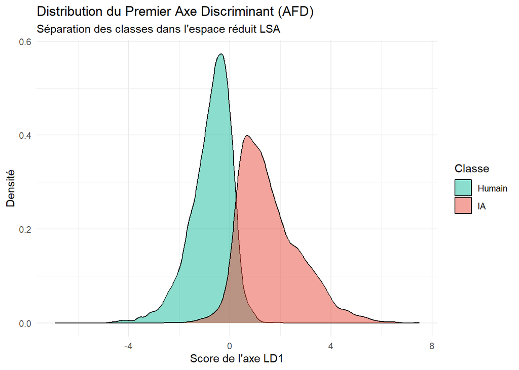

```r
# Librairie pour le Naive Bayes multinomial
library(naivebayes)

# --- 1. Naive Bayes ---
model_nb <- multinomial_naive_bayes(x = train_matrix, y = y_train)
pred_nb_class <- predict(model_nb, newdata = test_matrix)
pred_nb_prob <- predict(model_nb, newdata = test_matrix, type = "prob")[, "1"]
cm_nb <- confusionMatrix(pred_nb_class, y_test, mode = "prec_recall")

# --- 2b. AFD (LSA + LDA) ---
library(irlba)
library(MASS)

# 1. SVD sur la matrice d'entraînement (SPARSE)
# On convertit explicitement en dgCMatrix au cas où
train_matrix_sparse <- as(dfm_train, "dgCMatrix")
# SVD tronquée à 50 dimensions
svd_model <- irlba(train_matrix_sparse, nv = 50)

# Projection Train
lsa_train <- as.data.frame(as.matrix(svd_model$u %*% diag(svd_model$d)))
# IMPORTANT: s'assurer que l'ordre des lignes est respecté (normalement oui avec irlba sur matrice input)
lsa_train$label <- y_train

# 2. Entraînement LDA
model_afd <- lda(label ~ ., data = lsa_train)

# 3. Projection Test
test_matrix_sparse <- as(dfm_test, "dgCMatrix")
# Projection: Test_LSA = Test_Matrix * V
# Note: irlba renvoie V (right singular vectors).
# La projection correcte dans l'espace des documents est T * V.
lsa_test <- as.data.frame(as.matrix(test_matrix_sparse %*% svd_model$v))

# 4. Prédiction
pred_afd <- predict(model_afd, newdata = lsa_test)
pred_afd_class <- pred_afd$class
pred_afd_prob <- pred_afd$posterior[, "1"]

cm_afd <- confusionMatrix(pred_afd_class, y_test, mode = "prec_recall")

# 5. Visualisation de l'axe discriminant (LD1)
# On récupère les scores du premier axe (LD1) pour le jeu de test
ld_scores <- as.data.frame(pred_afd$x)
ld_scores$label <- y_test

ggplot(ld_scores, aes(x = LD1, fill = label)) +
  geom_density(alpha = 0.5) +
  scale_fill_manual(values = c("#18bc9c", "#e74c3c"), labels = c("Humain", "IA")) +
  labs(title = "Distribution du Premier Axe Discriminant (AFD)",
       subtitle = "Séparation des classes dans l'espace réduit LSA",
       x = "Score de l'axe LD1", y = "Densité", fill = "Classe") +
  theme_minimal()
```

La projection des données test sur le premier axe discriminant (LD1), obtenu après réduction LSA (50 dimensions) puis application de l’AFD, montre une différenciation globale entre les textes humains et les textes générés par l’IA. Les scores négatifs sont majoritairement associés aux textes humains tandis que les scores positifs correspondent aux textes IA. Un chevauchement persiste autour de la zone centrale indiquant que la séparation n’est pas parfaitement linéaire mais reste significative.

# 4 Résultats et évaluation

## 4.1 Performances comparatives

```r
extract_metrics <- function(cm, model_name) {
  data.frame(
    Modele = model_name,
    Accuracy = cm$overall["Accuracy"],
    Precision = cm$byClass["Precision"],
    Recall = cm$byClass["Recall"],
    F1_Score = cm$byClass["F1"]
  )
}

metrics_nb <- extract_metrics(cm_nb, "Naive Bayes")
metrics_afd <- extract_metrics(cm_afd, "AFD (sur LSA 50 dim)")
metrics_all <- rbind(metrics_nb, metrics_afd)

kable(metrics_all, digits = 4, caption = "Performances comparées sur le jeu de test") %>%
  kable_styling(bootstrap_options = c("striped", "hover"), full_width = F)
```

Performances comparées sur le jeu de test

|  | Modele | Accuracy | Precision | Recall | F1_Score |
| --- | --- | --- | --- | --- | --- |
| Accuracy | Naive Bayes | 0.9879 | 0.9874 | 0.9946 | 0.9910 |
| Accuracy1 | AFD (sur LSA 50 dim) | 0.9025 | 0.8803 | 0.9889 | 0.9314 |

## 4.2 Matrices de Confusion

#### 4.2.0.1 Modèle Naive Bayes

```r
# Affichage de la matrice de confusion Naive Bayes
kable(
  cm_nb$table,
  caption = "Matrice de Confusion - Naive Bayes",
  align = "c"
) %>%
  kable_styling(bootstrap_options = c("striped", "hover"), full_width = F)
```

Matrice de Confusion - Naive Bayes

|  | 0 | 1 |
| --- | --- | --- |
| 0 | 5895 | 75 |
| 1 | 32 | 2845 |

```r
cat("Vrais Positifs (IA correctement détectés) :", cm_nb$table[2,2], "\n")
```

```
Vrais Positifs (IA correctement détectés) : 2845
```

```r
cat("Faux Positifs (Humain classé IA) :", cm_nb$table[1,2], "\n")
```

[output not shown]

```r
cat("Vrais Négatifs (Humain correctement détectés) :", cm_nb$table[1,1], "\n")
```

```
Vrais Négatifs (Humain correctement détectés) : 5895
```

```r
cat("Faux Négatifs (IA classée humain) :", cm_nb$table[2,1], "\n")
```

[output not shown]

#### 4.2.0.2 Modèle AFD (LSA + LDA)

```r
# Affichage de la matrice de confusion AFD
kable(
  cm_afd$table,
  caption = "Matrice de Confusion - AFD (LSA 50 dim)",
  align = "c"
) %>%
  kable_styling(bootstrap_options = c("striped", "hover"), full_width = F)
```

Matrice de Confusion - AFD (LSA 50 dim)

|  | 0 | 1 |
| --- | --- | --- |
| 0 | 5861 | 797 |
| 1 | 66 | 2123 |

```r
cat("Vrais Positifs (IA correctement détectés) :", cm_afd$table[2,2], "\n")
```

```
Vrais Positifs (IA correctement détectés) : 2123
```

```r
cat("Faux Positifs (Humain classé IA) :", cm_afd$table[1,2], "\n")
```

[output not shown]

```r
cat("Vrais Négatifs (Humain correctement détectés) :", cm_afd$table[1,1], "\n")
```

```
Vrais Négatifs (Humain correctement détectés) : 5861
```

```r
cat("Faux Négatifs (IA classée Humain) :", cm_afd$table[2,1], "\n")
```

[output not shown]

## 4.3 Résumé comparatif

```r
comparaison <- data.frame(
  Aspect = c(
    "Vrais positifs (IA détectés)",
    "Vrais négatifs (humain détectés)",
    "Taux de détection (recall)",
    "Confiance (precision)",
    "Équilibre global (F1)"
  ),
  NaiveBayes = c(
    cm_nb$table[2,2],
    cm_nb$table[1,1],
    round(cm_nb$byClass["Recall"], 3),
    round(cm_nb$byClass["Precision"], 3),
    round(cm_nb$byClass["F1"], 3)
  ),
  AFD_LSA = c(
    cm_afd$table[2,2],
    cm_afd$table[1,1],
    round(cm_afd$byClass["Recall"], 3),
    round(cm_afd$byClass["Precision"], 3),
    round(cm_afd$byClass["F1"], 3)
  )
)

kable(comparaison, caption = "Synthèse des prédictions par modèle") %>%
  kable_styling(bootstrap_options = c("striped", "hover"), full_width = F)
```

Synthèse des prédictions par modèle

| Aspect | NaiveBayes | AFD_LSA |
| --- | --- | --- |
| Vrais positifs (IA détectés) | 2845.000 | 2123.000 |
| Vrais négatifs (humain détectés) | 5895.000 | 5861.000 |
| Taux de détection (recall) | 0.995 | 0.989 |
| Confiance (precision) | 0.987 | 0.880 |
| Équilibre global (F1) | 0.991 | 0.931 |

Globalement, le modèle Naive Bayes surpasse l’approche basée sur l’AFD après réduction LSA. Il présente un très faible nombre d’erreurs sur les faux positifs et les faux négatifs, montrant une excellente capacité de discrimination entre textes humains et textes générés par l’IA.

Ces résultats suggèrent donc que la représentation complète exploitée par le modèle bayésien est plus adaptée que l’espace réduit issu de la combinaison LSA + LDA.

## 4.4 Courbes ROC et analyse probabiliste

Comparaison des courbes ROC et analyse des seuils de décision.

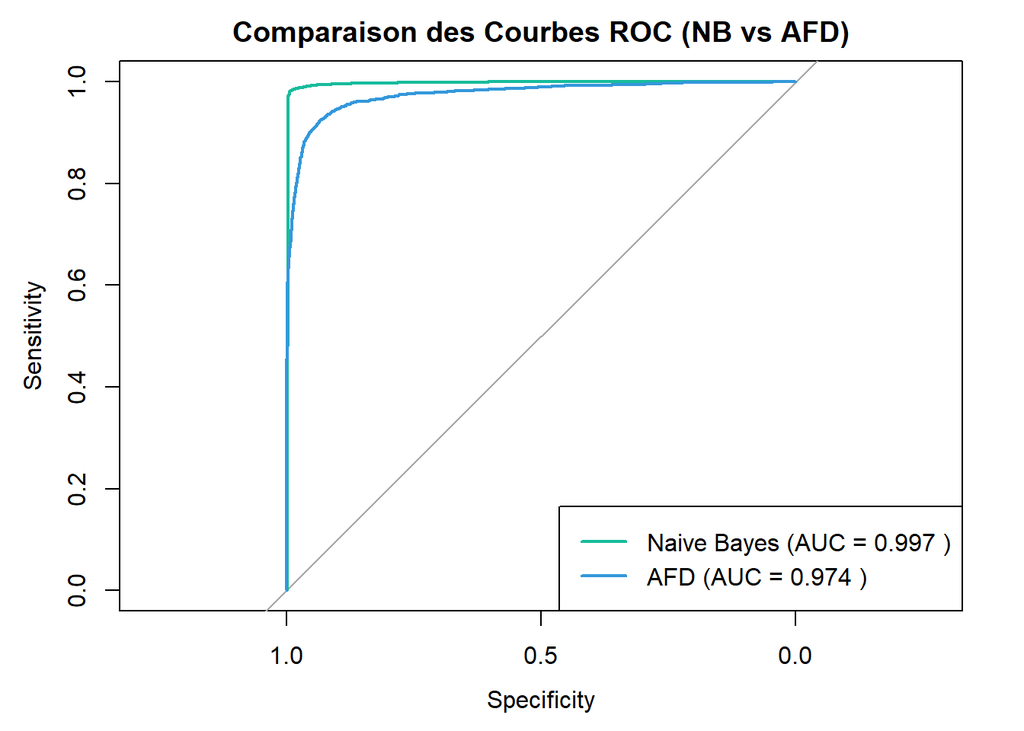

```r
if (!require("pROC")) install.packages("pROC")
library(pROC)

roc_nb <- roc(y_test, pred_nb_prob)
roc_afd <- roc(y_test, pred_afd_prob)


plot(roc_nb, col = "#18bc9c", lwd = 2, main = "Comparaison des Courbes ROC (NB vs AFD)")
plot(roc_afd, col = "#3498db", lwd = 2, add = TRUE)


legend("bottomright", legend = c(
    paste("Naive Bayes (AUC =", round(auc(roc_nb), 3), ")"),
    paste("AFD (AUC =", round(auc(roc_afd), 3), ")")
  ), col = c("#18bc9c", "#3498db"), lwd = 2)
```

### 4.4.1 Analyse AUC-ROC

L’**AUC (Area Under the Curve)** mesure la probabilité qu’un texte IA soit classé avec une probabilité plus élevée qu’un texte humain, indépendamment du seuil de décision.

- **AUC = 1.0** : Discrimination parfaite
- **AUC = 0.5** : Pas mieux qu’un tirage aléatoire
- **AUC > 0.7** : Bon modèle
- **AUC > 0.8** : Modèle très bon

```r
# Tableau comparatif des AUC
auc_table <- data.frame(
  Modele = c("Naive Bayes", "AFD (LSA 50 dim)"),
  AUC = c(round(auc(roc_nb), 4), round(auc(roc_afd), 4)),
  Interpretation = c(
    ifelse(auc(roc_nb) > 0.8, "Très bon", ifelse(auc(roc_nb) > 0.7, "Bon", "Moyen")),
    ifelse(auc(roc_afd) > 0.8, "Très bon", ifelse(auc(roc_afd) > 0.7, "Bon", "Moyen"))
  )
)

kable(auc_table, caption = "Comparaison des AUC-ROC", digits = 4) %>%
  kable_styling(bootstrap_options = c("striped", "hover"), full_width = F)
```

Comparaison des AUC-ROC

| Modele | AUC | Interpretation |
| --- | --- | --- |
| Naive Bayes | 0.9968 | Très bon |
| AFD (LSA 50 dim) | 0.9743 | Très bon |

L’analyse ROC confirme cette tendance : les deux modèles discriminent très bien mais Naive Bayes conserve un avantage stable quel que soit le seuil de décision.

# 5 Conclusion

L’ensemble des résultats montre que l’approche basée sur les n-grammes et le classifieur Naive Bayes offre d’excellentes performances pour la détection de texte généré par IA. L’analyse factorielle discriminante, bien qu’apportant une visualisation interprétable de la séparation des classes, reste légèrement en retrait en termes de performance brute.

Ces observations confirment, dans ce contexte, que la richesse de la représentation textuelle joue un rôle déterminant dans la qualité de la classification.

# 6 Travaux futurs

Plusieurs pistes d’amélioration peuvent être envisagées :

- **Enrichissement des caractéristiques linguistiques** : explorer des indicateurs stylométriques ou syntaxiques plus fins afin de mieux capter les différences subtiles entre textes humains et textes générés par l’IA.
- **Expérimentation de modèles hybrides ou plus expressifs** : tester des architectures plus complexes pour évaluer si elles permettent un gain supplémentaire en performance par rapport au modèle bayésien.
- **Adaptation aux modèles génératifs récents** : compte tenu de l’évolution rapide des LLM, ajuster l’approche à de nouvelles générations de modèles afin de garantir la robustesse du système dans le temps.